[figure not shown]

# Planning under uncertainty

AI-guided design of efficient clinical trials with BATON

Naim Rashid

Department of Biostatistics · Lineberger Comprehensive Cancer Center · UNC Chapel Hill

Computational Medicine Seminar · September 4, 2026

[figure not shown]

## Overview

Section 1

The problem: designing EVOLVE

- the ARPA-H ADAPT platform trial
- why standard design workflows break

Section 2

Our proposal: BATON

- model-guided search over trial designs
- choosing deliberately among designs that all work

Section 3

Does it work, and what did it change?

- validation, then the EVOLVE designs
- from one trial to the whole program

The problem

Designing EVOLVE

Why couldn’t we design this trial the usual way?

## ARPA-H ADAPT: the challenge

[figure not shown]

## The future state: measure before, during, and after treatment

**Current state**  
Static measurements for a dynamic disease. Biomarkers mostly assessed once, before treatment.

**ADAPT’s future state**  
Serial measurements as the tumor changes. Therapies switch as resistance traits appear.

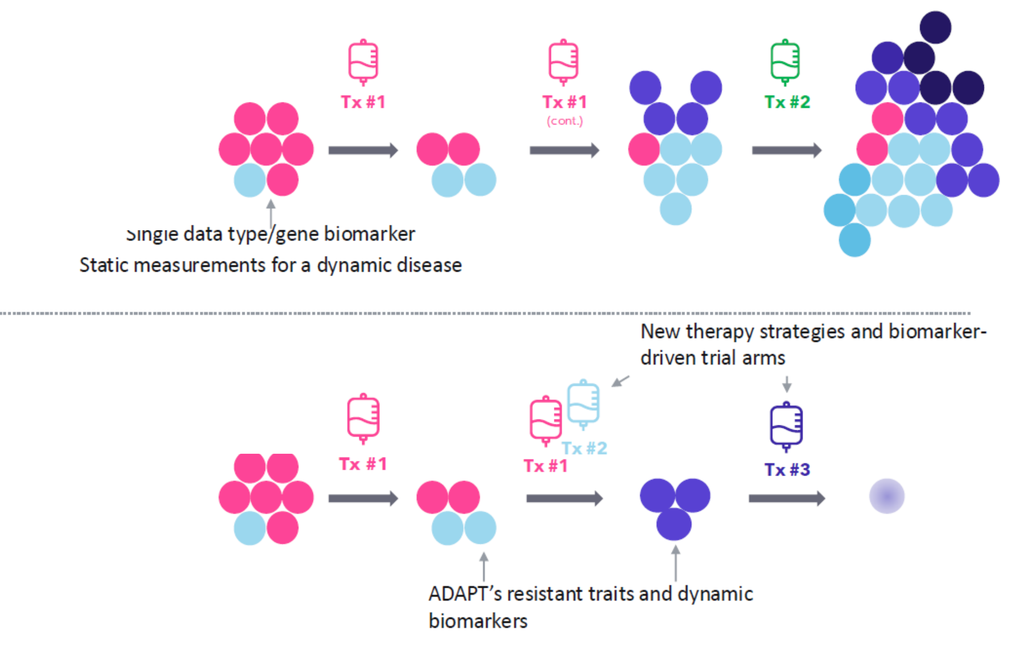

The trial has to keep measuring and keep deciding while patients are on it.

## ADAPT has three integrated components

[figure not shown]

Our team leads the clinical-trial component, and it has to react to what the rest of the program learns.

## Our piece: EVOLVE

[figure not shown]

## The trial had to learn while the program was running

*(ii) Clinical trial characteristics:*

1. Clinical trial for metastatic cancer patients.
2. Clinical trial that includes multiple lines of therapy under a single protocol.
3. Flexible clinical trial protocol that enables changes in design (e.g., randomized, adaptive, etc.).
4. Strong capability to collect tumor and blood-based measurements.
5. Possess a treatment line with a Progression Free Survival (PFS) rate of <9 months average.
6. Mechanisms for biomarker evaluation.
7. Modular clinical trial design enabling rapid dissemination and protocol uptake by different sites.

*(iii) General characteristics:* key clinical needs; evolutionary design examples and rapid-enrollment plans; treatment lines; biomarker testing and integration plans.

**New ask** (program-manager email): integrate an "N-of-1" trial component.

excerpts from the ARPA-H solicitation and program-manager correspondence

The ask: design an adaptive multi-line trial to discover, evaluate, and implement novel biomarkers, with an additional N-of-1 subcomponent

[figure not shown]

## These requirements collide with how trials are usually designed

|  | A typical trial | EVOLVE |
| --- | --- | --- |
| Designs needed | One | Many subtrials |
| Design timing | Fixed before launch | Repeatedly, on a clock |
| Design parameters | Few | Many, interacting |
| Power and type I error | Often closed-form | Simulation only |

## Frequentist trial designs have a convenient property

Assumed effect size + type I ceiling + power floor  
↓  
**minimum sample size N**

Simple designs: a formula gives N directly. Adaptive but frequentist designs, like Simon’s two-stage: exact calculation for every candidate, then complete enumeration. Either way, **computable**.

## Bayesian adaptive trials decide as they go. Each rule adds settings.

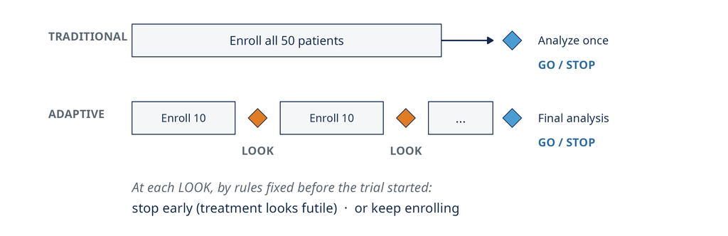

Posterior-based monitoring brings maximum N, look timing, futility (stop for lack of benefit) and efficacy thresholds, margins, priors, model settings: **8 to 13 interacting choices**, and every one changes how the trial behaves.

## No simple formulas for type I error or power here, so we count them

FDA typically wants **power of at least 0.80** and **type I error of at most 0.05 to 0.10**.

**Type I error (false go)**  
Simulate under the **null** (no effect). Fraction of trials that declare efficacy.

**Power (true go)**  
Simulate under the **alternative** (drug works as hypothesized). Fraction that declare efficacy.

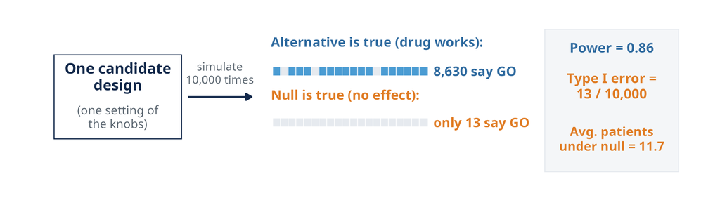

A design meeting your prespecified targets is **feasible**.

We know how to **evaluate** a design. We do not know **what to try next**.

## One subtrial became a two-week search

2 weeks

manual tuning of one subtrial’s design  
a Bayesian adaptive design with **8 interacting settings**: change one and power, type I error, and sample size all move

power stalled at 0.78, below the 0.80 floor

Several more subtrials were waiting. And is the design you settle on really the smallest one that works?

## Grid search and random search do not rescue us

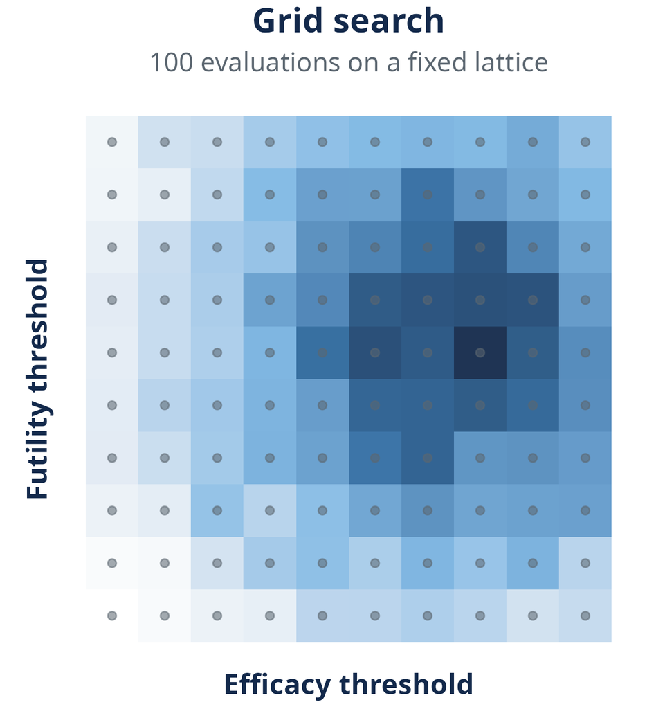

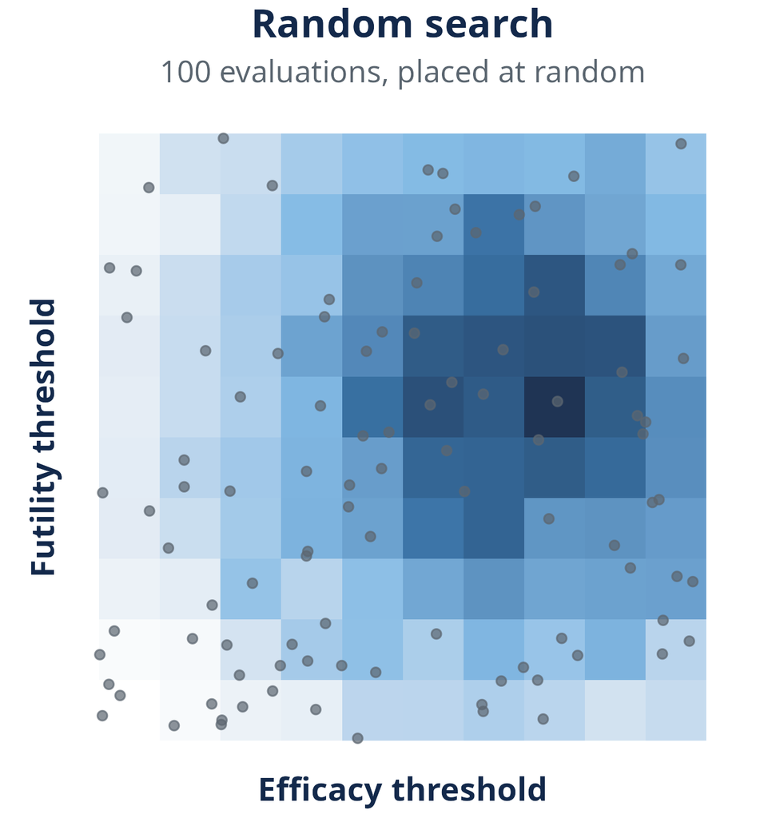

Grid explodes with dimension. Random, in our benchmark run of 2,000 evaluations, spent 93% of its budget on failing designs: **136 feasible, 6.8%**. (Darker = better design.)

## And we had to solve this repeatedly

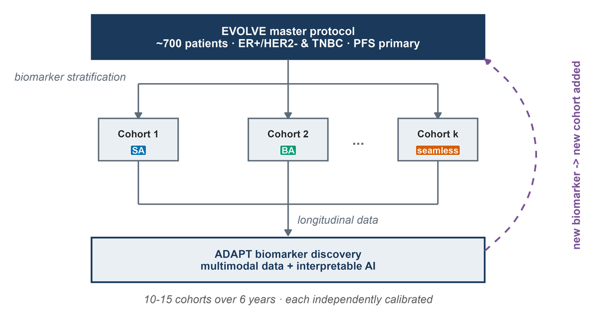

This was not one calibration problem. The platform needs **10 to 15 independent subtrials**, each with its own design, opened on a short clock.

## Not an EVOLVE problem: a Bayesian adaptive design problem

**Phase I dose-finding**  
escalation and safety rules tuned by simulation

**Phase II Bayesian designs**  
posterior thresholds and interim looks tuned by simulation

**Platform trials**  
every added feature adds settings that interact

Same shape every time: many interacting settings, behavior you can only get by simulation, and no tool that searches for you.

Our proposal

BATON

What should we simulate next?

## This is a familiar computational problem

**Machine learning**  
hyperparameters  
↓  
expensive training run  
↓  
validation performance

**Trial design**  
design parameters  
↓  
expensive Monte Carlo simulation  
↓  
power, type I error, enrollment

The same problem appears in hyperparameter tuning. The difference here: the answer must also satisfy **hard statistical constraints**.

## BATON turns calibration into a guided search

**BATON**  
Bayesian Adaptive Trial OptimizatioN  
Model-guided: a probabilistic model learns from the simulations already run and picks the next one worth paying for.

**You specify:** a power floor, a type I error cap, and what to minimize (expected N, maximum N, or a mix).

**Your simulator:** design settings plus null and alternative scenarios in; power, type I error, and enrollment out.

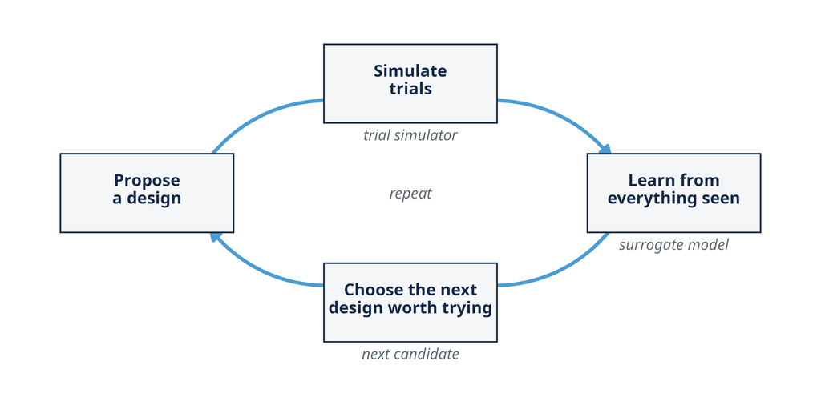

A closed loop: simulate, learn from everything seen so far, choose the next design, repeat.

## BATON starts with a small space-filling sample

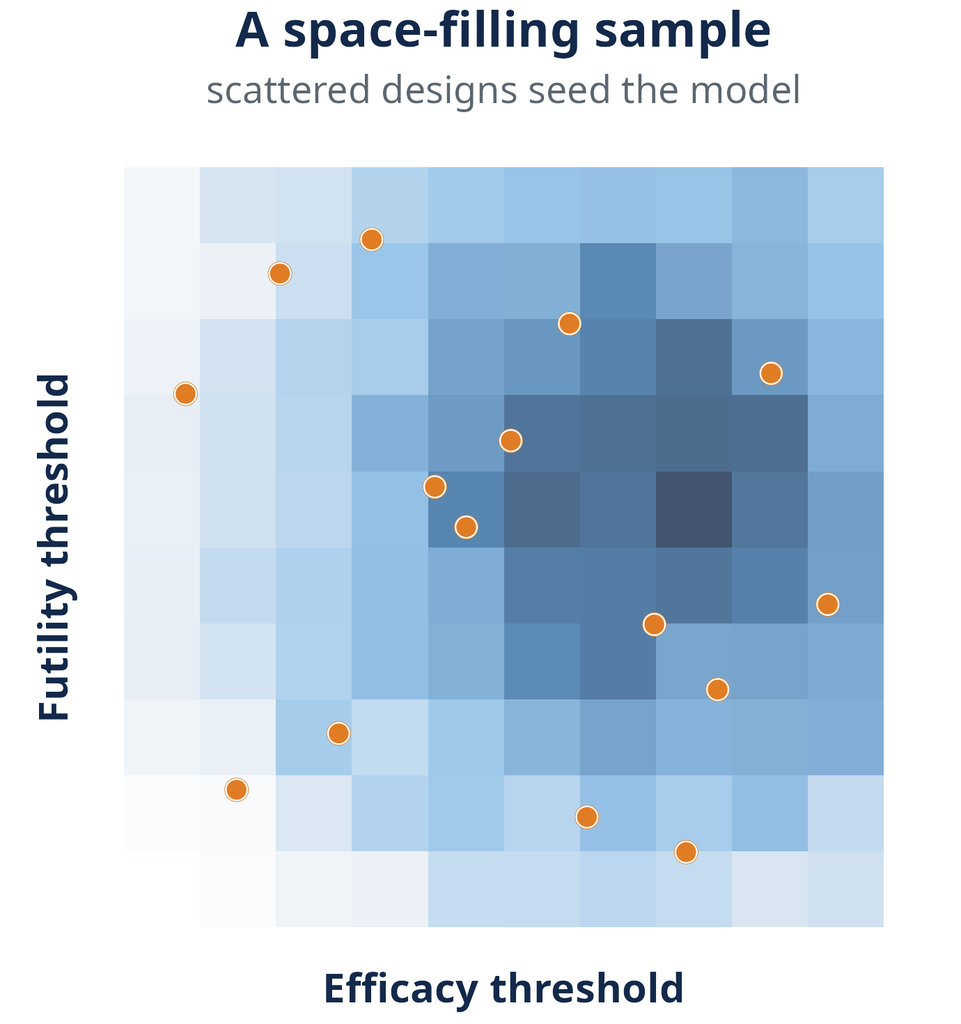

No lattice, no model yet: a handful of designs scattered across the space, just enough to sketch the landscape. (Darker = better design.)

## From simulations to a prediction model

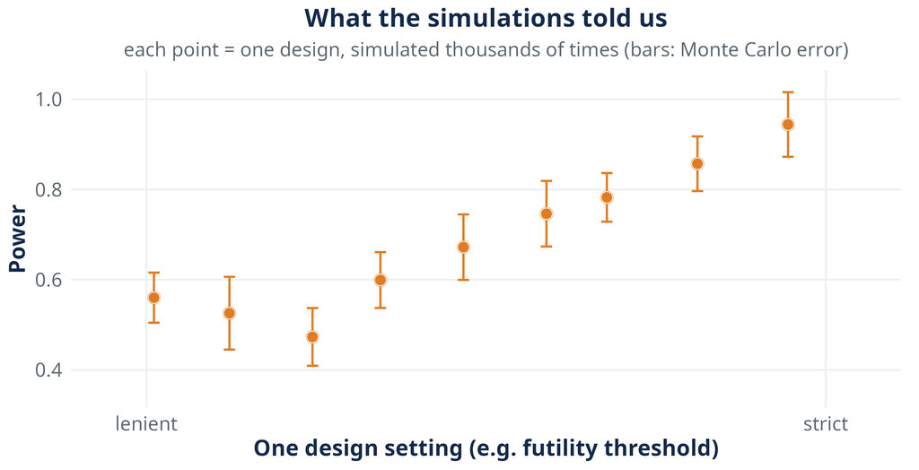

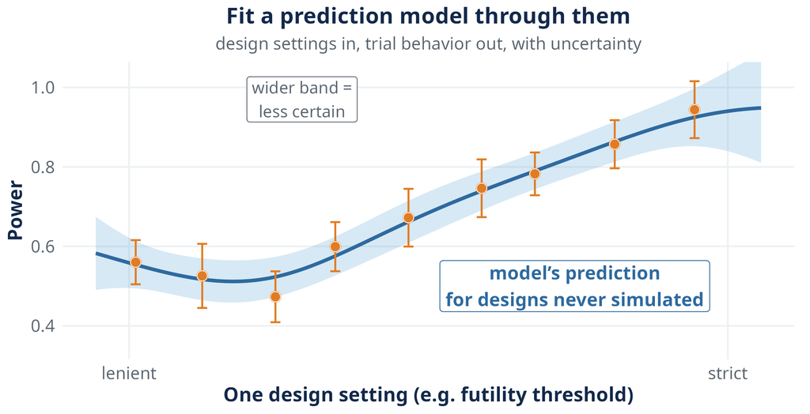

Design settings in, trial behavior out. The model predicts designs we have not paid to simulate, and says how sure it is.

## Where is the next simulation worth spending?

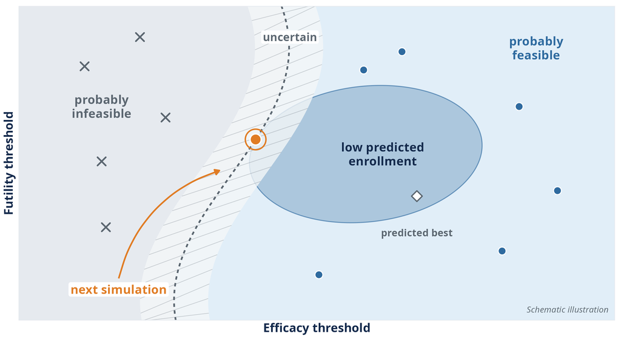

Not necessarily at the predicted best: where another expensive simulation is **most useful** for finding the feasible optimum.

## Now the model takes over

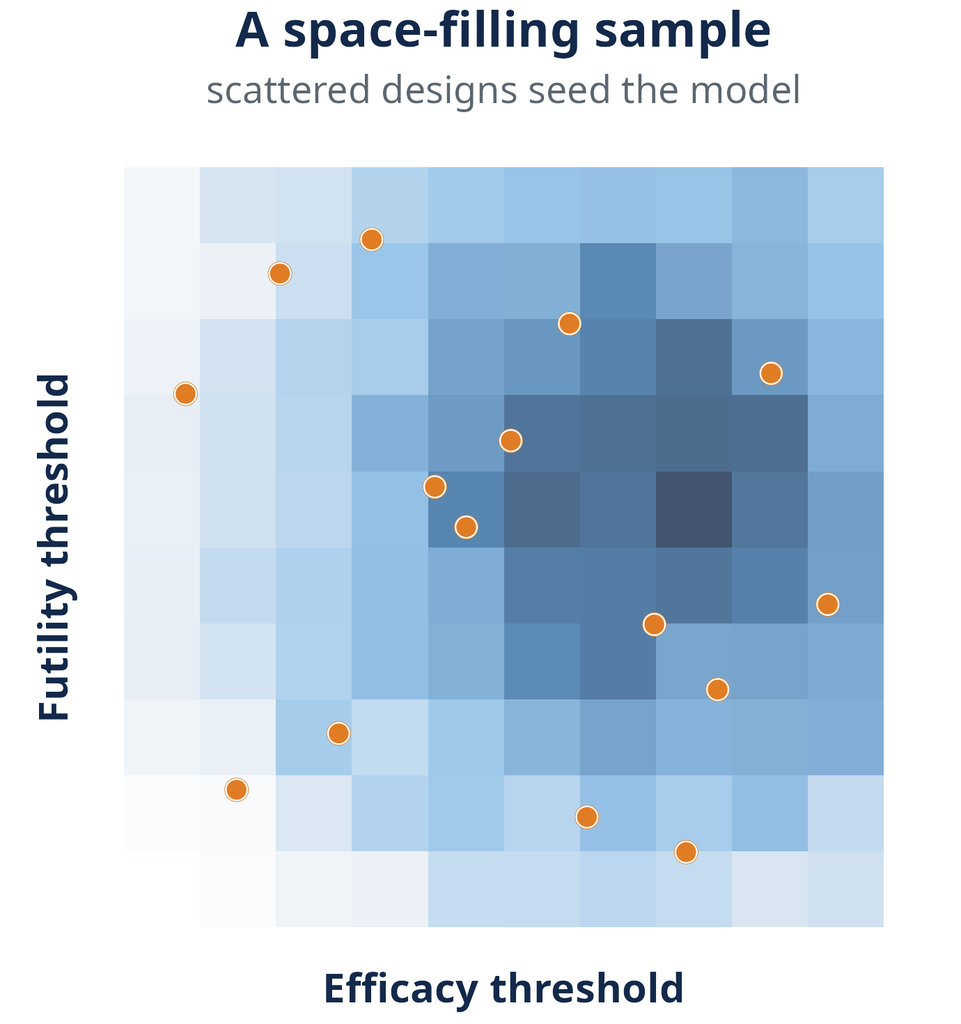

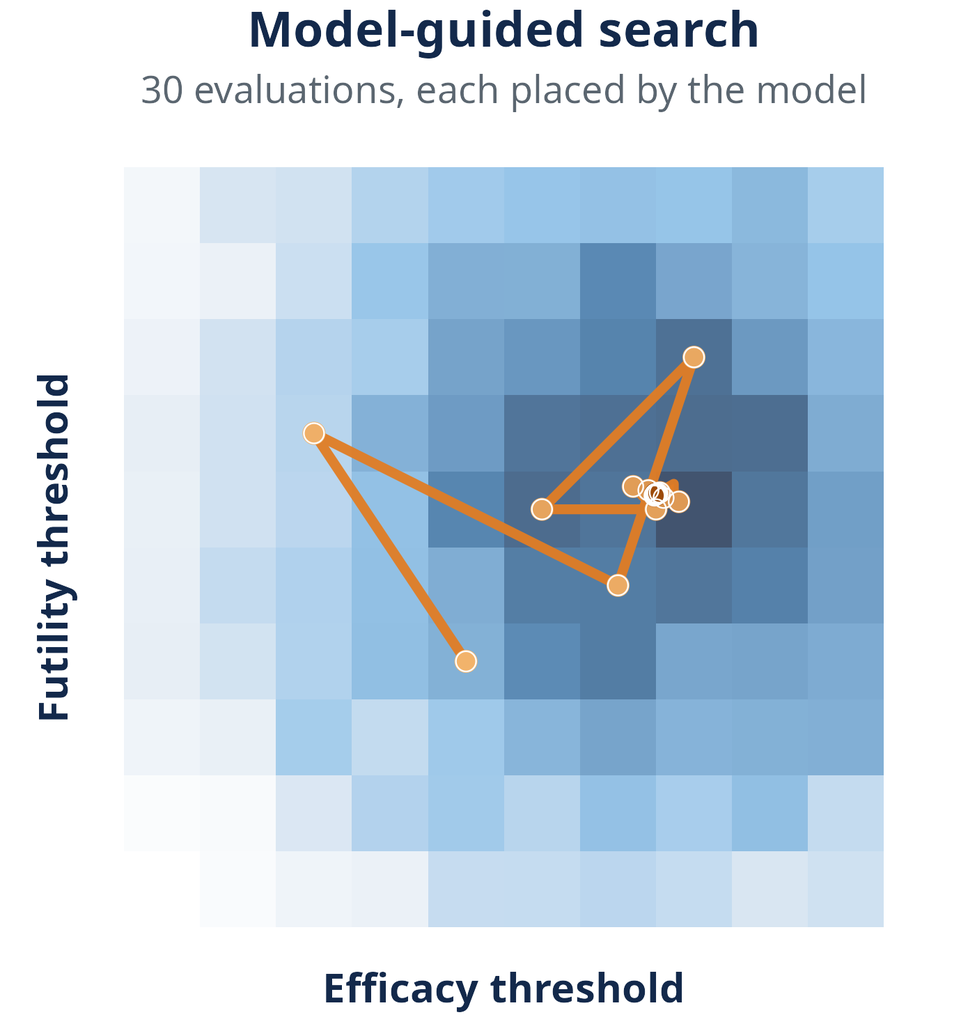

The seed sketches the map. After that, the model places every evaluation where information matters, homing in on the best feasible region.

## Spend precision where it matters

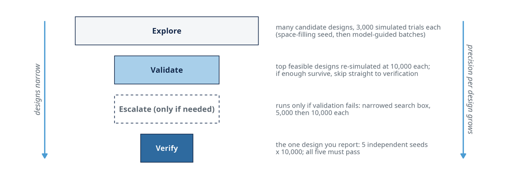

Cheap screening for the many, expensive re-checks for the few, and a separate multi-seed verification for the one design you report.

## Finding feasible designs is not the whole design problem

The feasible region can contain many designs that all satisfy power at least 0.80 and type I error at most 0.10.

Which one should we optimize for?

## Two designs. Both correct.

Calibrated under **different objectives**, both meeting the same requirements:

|  | Design A | Design B |
| --- | --- | --- |
| Maximum patients committed | **47** | **30** |
| Average patients *if the drug fails* | **11.7** | **22.8** |
| Power *(go when it works)* | 0.86 | 0.94 |
| Type I *(false go)* | 0.001 | 0.021 |

One quits losers quickly. One caps the worst-case commitment. Neither is universally better.

## The objective should reflect the trial you actually want

A feasibility criterion tells us whether a design is acceptable. It does not encode which acceptable design we **prefer**.

#### “Quit losers quickly”

H0-Optimal

Minimize average N when the drug fails.  
*Tradeoff: may need a larger maximum N.*

#### “Cap the worst case”

Minimax

Minimize maximum N.  
*Tradeoff: more patients when the drug fails.*

#### “The compromise”

Admissible

Weighted blend of the two.  
*Trades one against the other, explicitly.*

Frequentist two-stage designs made these tradeoffs explicit for decades. **BATON transports them into complex adaptive designs where exhaustive enumeration is impractical.**

The evidence

Does it work?

And did it change anything?

## First, a problem where the answer is known

Simon two-stage designs: every possible design can be enumerated, so the exact optimum is known. **One benchmark scenario, 10 independent BATON runs.**

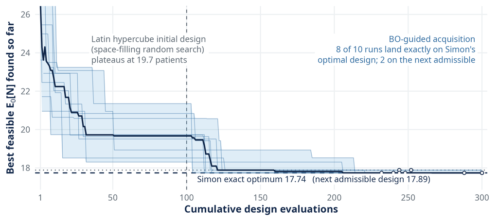

**10 independent random starts:** 8 return Simon’s exact optimal design; 2 land on a near-neighbor 0.15 patients away.

## Across 12 different benchmark scenarios

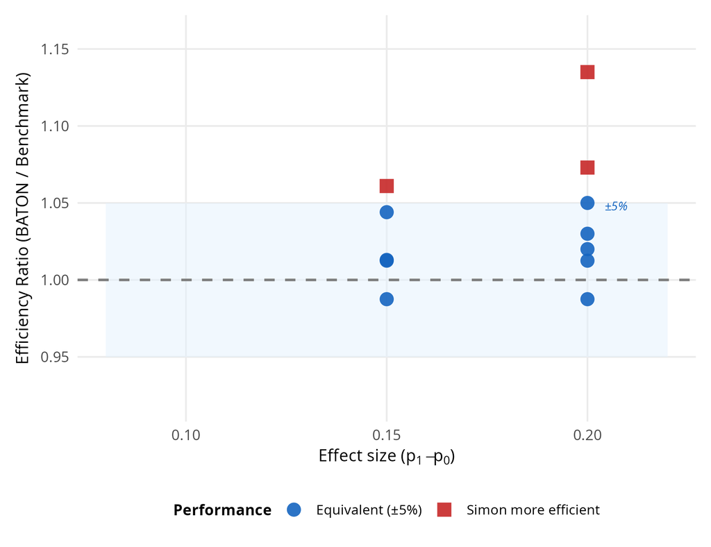

Always feasible: **12 of 12**. Exact optimum in **4 of 12**; median within **2.5%**; worst case **13.5%**.

Primary target: verified feasibility. Objective optimization is approximate in an expensive, noisy, discrete space.

## The same tradeoff appears in EVOLVE’s Bayesian adaptive trial

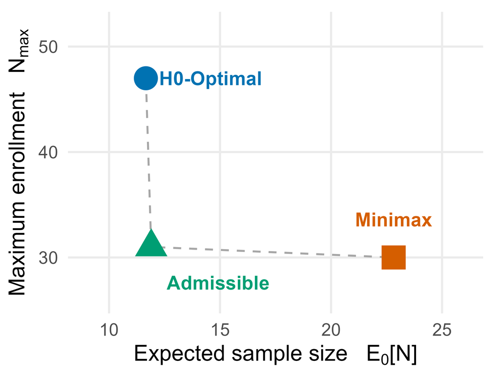

**The platform’s TNBC cohort**

- quit losers quickly: 47 max, **11.7** if inactive
- the compromise: 31 max, **11.9**
- cap the worst case: 30 max, **22.8**

The compromise keeps almost all of H0-Optimal’s efficiency at almost Minimax’s cap.

## Richer designs: 8 knobs become 13

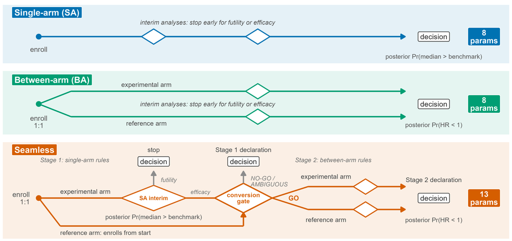

Seamless: screen cheaply single-arm, then demand randomized evidence from promising cohorts. Thirteen interacting parameters make manual calibration impractical.

## Sometimes two philosophies become the same design

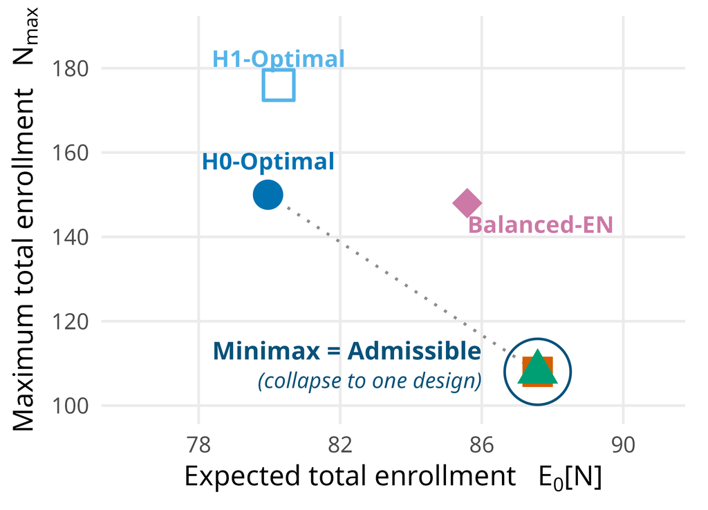

Minimax and Admissible calibrate to the **identical 13-parameter design**: not a coincidence but a structural alignment, visible directly in the conversion rates.

## The mechanism: a gate that rarely opens when the drug fails

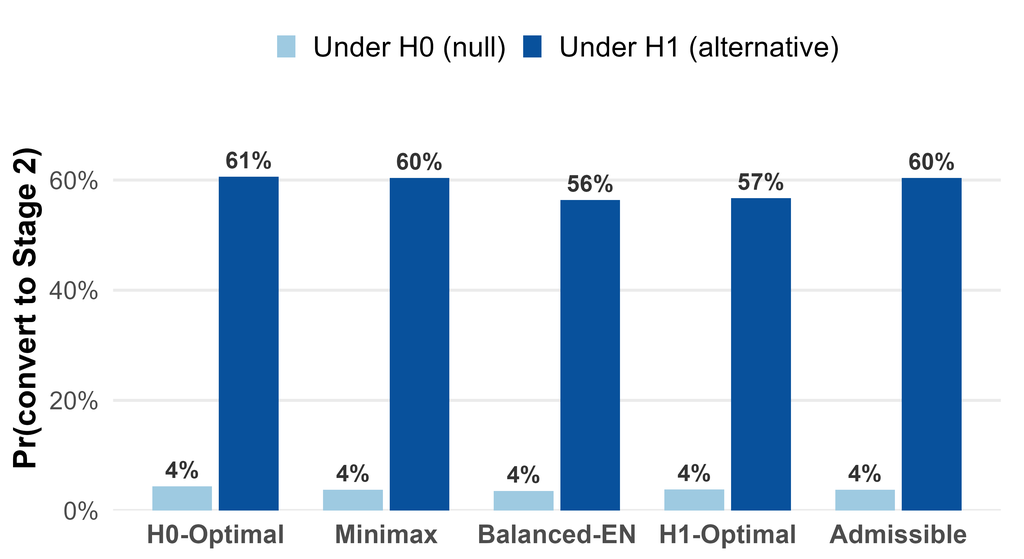

When the drug fails, only ~4% of trials reach stage 2, so stage 1 dominates enrollment, bringing the Admissible and Minimax objectives into alignment. **The search became an instrument for understanding the design.**

## BATON changed decisions in EVOLVE

**Capacity**: maximum N locked ~3 months before first enrollment, from frontier curves.

**Program planning**: enrollment and timeline projections across 10 to 15 sequential subtrials.

**Interim data locks**: look spacing sets the analysis calendar the safety board shares.

**Turnaround**: a feasible design in under 45 minutes per run; full workflow about 4 hours.

In practice we generally settled on the **Admissible** designs: efficient enrollment, early stopping, bounded capacity.

## From EVOLVE to a general framework

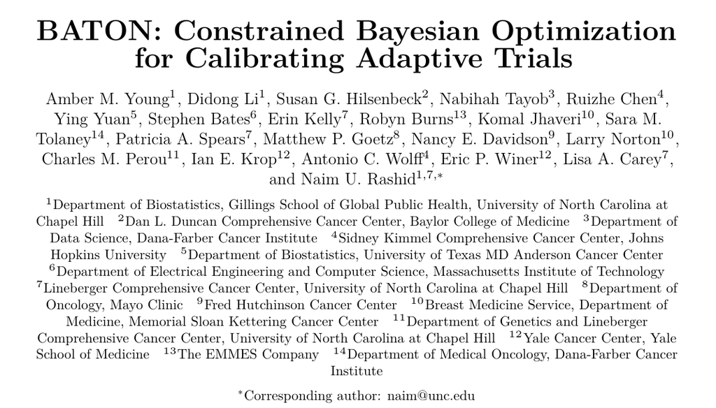

[figure not shown]

- under review at JASA
- open-source R package
- bring your own trial simulator

## A trial can succeed locally while the development program fails

54%  
of 640 therapeutics reaching phase 3 or pivotal trials **failed in late-stage development**; 57% of failures for inadequate efficacy

21 of 138  
new oncology drugs carried **dose-optimization postmarketing requirements**; median 6 years to fulfill

Each trial can be well designed locally while the program remains poorly optimized globally.

Hwang et al., JAMA Internal Medicine 2016 · FDA dose-optimization postmarketing requirements, 2010 to 2022 oncology approvals

## Early decisions become downstream commitments

**Sotorasib (KRAS G12C)**  
**960 mg**: highest dose tested in phase I  
↓ carried forward  
selected for development, then approval  
↓ after approval  
FDA required a **240 vs 960 mg** comparison  
↓  
**similar progression-free survival at one-quarter the dose**

A dose decision good enough to advance development left a fundamental question unresolved into the post-approval setting.

FDA Oncologic Drugs Advisory Committee review of sotorasib dosing and CodeBreaK 200, October 2023

## From trial optimization toward phaseless development

#### Across possible futures

BATON-C · in progress, with Amber Young

Optimize across a *prespecified family* of plausible clinical futures, not one assumed truth.

#### Earlier in development

BATON-D · in progress, working name

Optimize dose-finding rules for safety *and* what every later trial inherits.

#### Across trials

phaseless development · long-term goal

Optimize dose, population, interim, and confirmatory decisions as *one linked program*.

The goal: continuously learning development programs that reach reliable answers with fewer patients, less elapsed time, and lower development cost.

## We optimize the trial. The program is what succeeds.

**Phase I**  
choose dose

selection inherited  
→

**Phase II**  
choose population, signal

debt accumulates  
→

**Confirmatory trial**  
must repay remaining debt

**What if we reverse the logic?**  
**final therapeutic claim** + its evidentiary requirements  
↓  
simulate alternative development architectures  
↓  
phased · seamless · **potentially phaseless**

Phase structure becomes a design variable.

## What I hope you remember

1. Simulation can tell us how a proposed adaptive trial behaves, but not what design to try next.
2. BATON turns trial calibration into a guided, constrained search, and makes the tradeoffs among workable designs explicit.
3. The larger opportunity: optimize the **sequence of decisions** across development, toward programs that reach reliable answers faster, with fewer patients.

## Acknowledgments

#### EVOLVE / ADAPT

- MPIs: Lisa Carey (UNC), Ian Krop (Yale), Chuck Perou (UNC), Eric Winer (Yale), Antonio Wolff (Hopkins)
- EVOLVE steering committee and site investigators across 15 TBCRC sites
- ARPA-H ADAPT program leadership

#### Statistics / BATON

- **Amber Young** (UNC), who led BATON's design and validation, and co-leads BATON-C
- **Didong Li** (UNC) · **Dinelka Nanayakkara** (ARPA-H statistics group)
- Statistical working group: Ruizhe Chen (Hopkins), Sue Hilsenbeck (Baylor), Nabihah Tayob (DFCI)
- Rashid Lab

FUNDING · ARPA-H 140D042590009 · NCI P50-CA257911 (UNC SToP SPORE) · DOD HT9425241103100121 · NCI U01-CA274298

Thank you

Questions

naim@unc.edu · rashidlab.github.io  
BATON R package: github.com/naimurashid/BATON · manuscript under review at JASA

Backup

Reference slides

## Backup: the surrogate and the acquisition

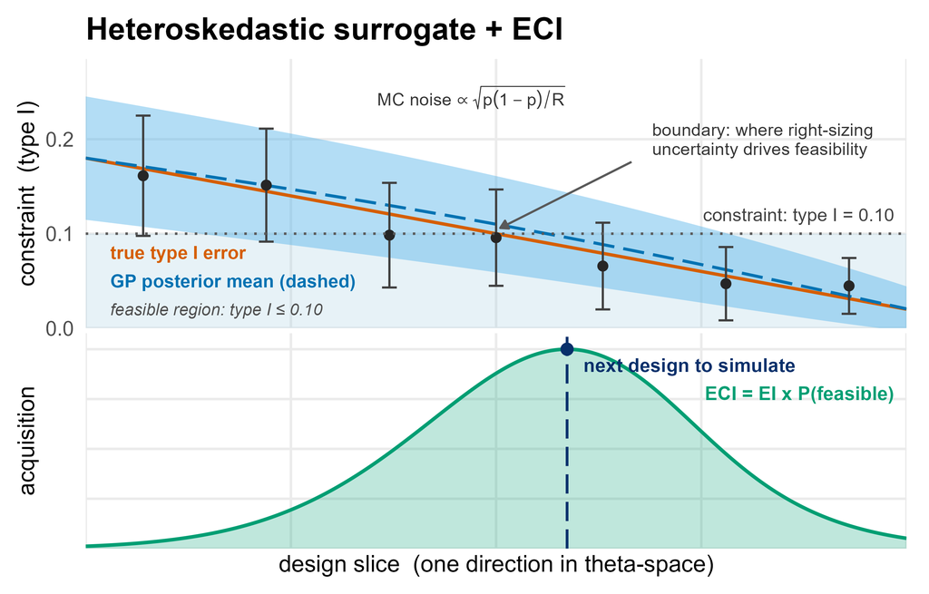

- One GP surrogate per behavior metric (power, type I, expected enrollments).
- **Heteroskedastic** noise model: Monte Carlo variance differs across the space (early-stopping designs give noisier estimates per replication), and hetGP models it rather than assuming it constant.
- Acquisition: **expected constrained improvement**, expected objective gain multiplied by the modeled probability that *every* constraint is satisfied.
- Batched proposals; constraint estimates carry their Monte Carlo standard errors into the model.

## Backup: Simon benchmark, per-scenario

All 12 binary-endpoint benchmark scenarios, BATON vs. the enumerated Simon-optimal design:

| Claim | Value |
| --- | --- |
| Scenarios where BATON’s design is feasible | 12 / 12 |
| Scenarios where BATON returns the exact Simon design | 4 / 12 |
| Median ratio of expected null sample size, BATON / Simon | 1.025 |
| Worst-case ratio | 1.135 |
| Best-case ratio | 1.000 |

Interpretation: on a discrete design lattice many near-optimal designs sit within Monte Carlo resolution of one another; BATON lands on the optimum or a near-neighbor, and never on an infeasible design.

## Backup: the manual-versus-BATON comparison, in full

**Manual tuning (the TNBC cohort)**  
Two weeks of expert effort produced **no feasible design**. The best manual single-arm point reached power 0.78 at an average null enrollment of 39.2: infeasible on power.

**BATON**  
Found a feasible design (average null enrollment 11.7, power 0.86). Full production workflow about 4 hours wall-clock; a single calibration run under 45 minutes.

An illustrative single comparison (documented in the paper’s web appendix), not a controlled benchmark across analysts. Same simulator, same constraints.

## Backup: what the constraints and parameters actually are

**Calibrated (searched) parameters, single-arm:**

- maximum enrollment; interim spacing; minimum-events gate before decisions count
- posterior futility threshold; posterior efficacy threshold
- decision margin over the historical benchmark
- analysis-prior concentration; hazard-model resolution (piecewise intervals)

Seamless adds conversion-gate thresholds and second-stage sample-size and stopping parameters (13 total).

**Constraints (headline scenarios):**

- type I error at most the ceiling (0.10 in the scenarios shown)
- power at least the floor (0.80)
- seamless designs add gate-behavior constraints (null conversion rate bounded, alternative conversion rate floored)

**Objectives, by philosophy:** expected null enrollment (H0-Optimal), maximum enrollment (Minimax), weighted blends (Admissible family), expected alternative enrollment (H1-Optimal).

Scenario A truths: null median 3.8 months, alternative 9 (hazard ratio 0.42), Weibull shape 1.3, accrual 2 per month; maximum enrollment searched in [30, 120]. Two Simon scenarios use a 0.05 ceiling with 0.90 power.

## Backup: related work and what BATON adds

**Existing approaches**

- **BOP2 / GBOP2** (Zhou; Zhao): grid or particle-swarm search over posterior-probability stopping thresholds; return one design under one criterion.
- **Operating-characteristic acceleration** (Golchi 2022): speeds the estimation, does not optimize the design.
- **Single-objective BO for trial design** (Richter 2022): one objective, without multi-constraint feasibility.
- **gsDesign / rpact / BATSS**: group-sequential and frequentist tooling.

**What BATON adds, jointly in one framework**

1. finds **feasible** designs under **multiple noisy** behavior constraints;
2. models **heteroskedastic** Monte Carlo error;
3. optimizes under **philosophy-specific** sample-size objectives.

It exposes the trade-off surface, and reveals **when philosophies coincide and why**.

## Backup: known failure modes and limits

- **Budget exhaustion**: 3 of 10 reproducibility runs used the full 300-evaluation budget rather than stopping early; quote evaluations used, not “convergence.”
- **Approximate optimization**: worst benchmark gap 13.5% from the enumerated optimum (single seed); the guarantee is high-fidelity feasibility, not exact optimality.
- **Correlated constraints**: the acquisition multiplies marginal feasibility probabilities; latent surfaces for power and type I error can be correlated. Affects the search only; reported designs are verified directly.
- **No common random numbers in the loop**: candidate comparisons carry full independent Monte Carlo noise; verification uses a shared seed set.
- **One assumed truth per calibration**: every current result conditions on an assumed clinical scenario; robustness across scenarios is BATON-C, in progress.

## Backup: bidirectional stopping variants

The single-arm and between-arm headline scenarios use futility-only interim stopping (interims can stop for futility; efficacy is decided at the end). The seamless design is calibrated with bidirectional stopping throughout, because its conversion gate is efficacy-driven. The paper’s supplement repeats the single-arm and between-arm calibrations with **bidirectional** stopping, where interims may also stop early for efficacy.

- The frontier structure persists, but the philosophies compress: under bidirectional stopping in Scenario A, H0-Optimal and Admissible calibrate to the same maximum enrollment (31), separating only in thresholds.
- Expected enrollment under the alternative drops substantially (early efficacy stopping pays off exactly when the drug works).
- The choice between stopping structures is itself a design decision upstream of the philosophy choice.

## Backup: what I am not arguing

**Not** that trials are currently miscalibrated. Feasible designs found by hand are feasible. The claim is that the *choice among them* has been invisible.

**Not** that one philosophy is right. H0-Optimal and Minimax encode different, legitimate priorities. The method is deliberately neutral among them.

**Not** that optimization replaces statisticians. It replaces the *grid search* part of their month, not the judgment part.

## Backup: ten seeds, one design

The whole pipeline, rerun end to end at ten independent random seeds:

| Runs returning a feasible design | **10 / 10** |
| --- | --- |
| Runs returning Simon’s exact optimal design | **8 / 10** |
| Expected null enrollment, mean (spread) | **17.77** (0.06) |
| Evaluations used, median | 250 of a 300 budget |

The other two seeds return a near-neighbor design (capacity 29 instead of 25) whose expected enrollment differs by 0.15 patients. What reproduces is the design’s behavior, and usually the design itself.

For a method meant to sit inside regulatory submissions, this is not a nicety. It is what regulatory credibility requires.

## Backup: the randomized-cohort frontier

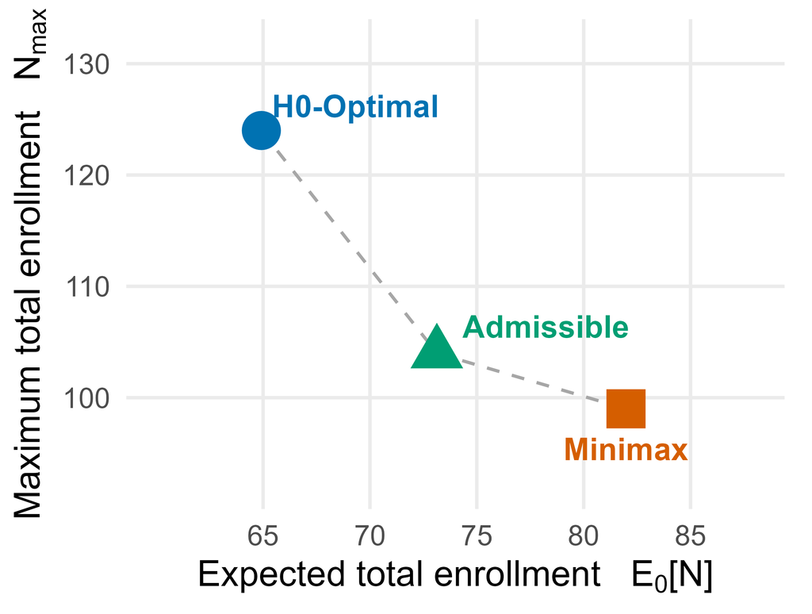

Cutting the worst-case cap from 124 to 104 costs about 8 extra patients on average when the treatment does not help; the next 5 cost about 9 more.